# Among U.S. children aged 0–17, is low birth weight associated with increased odds of an ever asthma diagnosis, after adjusting for child age, sex, race/ethnicity, household income, and secondhand smoke exposure?

- Show All Code
- Hide All Code
- View Source

Author

University of Massachusetts - Amherst

Javier Diaz Collante

Rachel Huselid,

Anjelica Martinez

Department of Biostatistics & Epidemiology

Created on: June 28, 2026

Purpose

This notebook is for the analysis portion of our EPI 690A final project.

# Introduction

Asthma is one of the most common chronic diseases of childhood in the United States and is a leading cause of emergency department visits, hospitalizations, missed school days, and reduced quality of life in children. Although genetic predisposition contributes to asthma risk, early-life factors have also been recognized as important determinants of many chronic diseases. Low birth weight, often resulting from preterm birth or other factors, has been associated with underdeveloped lung development and increased susceptibility to respiratory disease later in childhood. However, because childhood asthma is also influenced by demographic, socioeconomic, and environmental factors, it is important to evaluate whether the relationship between low birth weight and asthma persists after accounting for these potential confounders.

Using data from the 2023 [National Survey of Children’s Health (NSCH)](https://mchb.hrsa.gov/data-research/national-survey-childrens-health) a nationally representative cross-sectional survey of U.S. children aged 0–17 years, this project will examine whether low birth weight is associated with the likelihood of ever receiving an asthma diagnosis. Specifically, the research question is: among U.S. children aged 0–17 years, is low birth weight associated with increased odds of ever having an asthma diagnosis after adjusting for age, sex, race, household income, and secondhand smoke exposure? We hypothesize that children with a history of low birth weight will have a higher likelihood of ever being diagnosed with asthma compared with children of normal birth weight, even after controlling for these possible confounders.

# Methods

## Study population

The 2023 National Survey of Children’s Health (NSCH) survey population focused on non-institutionalized children in the United States ages 0–17. The sample size nationally was 55,162 children, and the state sample size ranged from 710 to 4,696 children. Participants were randomly sampled by household and contacted by mail directly to determine whether the household had one or more children under the age of 18. If the household was determined to have more than one child, one child was chosen at random to be the subject of the survey. Children with special health care needs and children between the ages of 0 and 5 were oversampled in the survey. A total of nine states and one metropolitan area (California, Colorado, Nebraska, New York, Ohio, Oregon, Pennsylvania, Tennessee, Wisconsin, and Atlanta, Georgia) provided oversampling funding to support additional interviews and allow reporting for specific population groups, conditions, or localities in these locations. The survey data were weighted to represent the population of non-institutionalized children between the ages of 0 and 17 both nationally and by state. The overall weighted response rate of the survey was 35.8%.

The survey data were collected via online forms or a physical paper version. Each household was mailed an invitation in which the adult of the house familiar with the child’s health and health care was asked to complete a short screener questionnaire (via web or paper). The questionnaire asked participants to identify whether there were children in the household between the ages of 0 and 17 and to report their ages. If a child was in the home and the participant wished to complete the survey online, they were directed to a link with more detailed age-specific questions for the one randomly selected child. The survey was provided in both English and Spanish. Participants also had the option to use telephone assistance.

## Exposure

The primary exposure was birth weight status, defined using the variable `BIRTHWT_L`, which classifies children as having low birth weight (less than 2,500 grams) or normal birth weight. Low birth weight was treated as a binary variable, with normal birth weight as the reference group. This variable is provided as a pre-derived field in the NSCH public use file and required no additional recoding.

## Outcome

The primary outcome was ever having received an asthma diagnosis, defined using the variable `K2Q40A`, which asks whether a doctor or other health care provider has ever told the respondent that the child has asthma. This was treated as a binary outcome, with children never diagnosed with asthma serving as the reference group. We initially considered distinguishing children with current versus previous asthma diagnoses using the companion variable `K2Q40B`, but ultimately used the single binary ever asthma variable for all descriptive and modeling purposes, since it captures any lifetime occurrence of the diagnosis and avoids ambiguity in how to classify children whose asthma has resolved.

## Covariates

Covariates were selected based on their established or plausible relationship to both birth weight and childhood asthma risk, and on the completeness of their measurement across the full 0 to 17 age range. The fully adjusted model included child age, sex, race, preterm birth status, familial poverty ratio, highest level of parental education, insurance type, and household smoker status (secondhand smoke exposure). The research question names the primary confounders of interest (age, sex, race/ethnicity, household income, and secondhand smoke exposure) while the fully adjusted model additionally accounts for preterm birth, parental education, and insurance type, each an established correlate of both low birth weight and childhood asthma. Household income was operationalized as the familial poverty ratio (FPL). Age was included in the overall adjusted model but was excluded from the covariate set in age stratified analyses, since age itself defines the stratification.

Vaping exposure inside the home and allergy history were described in the study population but were not included in the adjusted model. These variables were treated separately because our adjustment strategy prioritized demographic and socioeconomic covariates with minimal missingness, and because including additional covariates would have further reduced the analytic sample available for the fully adjusted model. Body mass index category was considered but excluded from all models, since this measure is only collected for children ages 6 to 17 and is therefore missing for the majority of younger children in the sample. In addition, because body mass index is measured cross sectionally at the time of the survey, it cannot be used to establish whether excess weight preceded or followed an asthma diagnosis.

## Statistical Methods

Within this population, our analytic sample was further restricted to children with non-missing responses for the primary exposure and outcome variables, since these two variables define the research question. A flow diagram will report the sample size at each stage of this restriction, from the total NSCH respondent pool through the final analytic sample, along with the number of children excluded at each step. Missing covariate data was not used to exclude children from the overall analytic sample or from unadjusted analyses; rather, covariate missingness was allowed to reduce the sample size only within models that included the affected covariate.

We retained the full pediatric age range of 0 to 17 years for our primary analysis, since restricting the sample by age would have limited the birth weight information available for the youngest children, who are closest in time to their birth history. However, because asthma diagnoses accumulate over childhood and younger children have had less opportunity to be diagnosed, we conducted a parallel analysis stratified by age group to evaluate whether the association between birth weight and asthma differed across developmental stages.

The association between birth weight status and ever having an asthma diagnosis was estimated using logistic regression, and results are presented as both prevalence differences and odds ratios with accompanying 95% confidence intervals, since absolute and relative measures each provide distinct and clinically relevant information. Prevalence differences were estimated as average marginal effects, averaging the difference in predicted asthma probability across all observations in the sample. We used this approach rather than evaluating the contrast at a single representative covariate profile, which yields wider standard errors and is more sensitive to the choice of profile values. Models were built in a staged sequence to account for the effect of missing covariate data on sample size. The first model was unadjusted. The second model adjusted for child age alone, since age was fully observed and allowed us to assess confounding by age before introducing covariates with missing values. The third model was fully adjusted for sex, race, preterm birth, familial poverty ratio, parental education, household smoker status, and insurance type. The analytic sample size is reported for each stage of this sequence.

Finally, the fully adjusted model was repeated separately within four age strata, infants and toddlers (0 to 2 years), preschool age (3 to 5 years), middle childhood (6 to 12 years), and adolescents (13 to 17 years), to evaluate whether the association between birth weight and asthma diagnosis was consistent across childhood or concentrated within a particular developmental period.

# Codebook

| **New Variable** | **Original Variable** | **Label** | **Values** |
| --- | --- | --- | --- |
| `age` | `SC_AGE_YEARS` | Age of selected child (years) |  |
| `sex` | `SC_SEX` | Sex of selected child | 1 = Male 2 = Female |
| `race` | `SC_RACE_R` | Race of selected child | 1 = White alone 2 = Black or African American alone 3 = American Indian or Alaska Native alone 4 = Asian alone 5 = Native Hawaiian and Other Pacific Islander alone 7 = Two or More Races |
| `hispanic` | `SC_HISPANIC_R` | Hispanic or Latino origin of selected child | 1 = Yes 2 = No |
| `birth_weight_status` | `BIRTHWT` | Birth weight status | 1 = Very low birth weight (less than 1,500g) 2 = Low birth weight (less than 2,500g) 3 = Not low birth weight |
| `birth_weight_ver_low` | `BIRTHWT_VL` | Birth weight is very low (<1500g) | 1 = Yes 2 = No |
| `birth_weight_low` | `BIRTHWT_L` | Birth weight is low (<2500g) | 1 = Yes 2 = No |
| `asthma` | `K2Q40A` | Ever diagnosed with asthma | 1 = Yes 2 = No |
| `born_early` | `K2Q05` | Born 3 or more weeks before due date | 1 = Yes 2 = No |
| `poverty` | `FPL_I1` | Family poverty ratio, first implicate | 50 or less - 400 or more |
| `education` | `HIGRADE_TVIS` | Highest level of education among reported adults, Detailed | 1 = Less than high school 2 = High school (including vocational, trade, or business school) 3 = Some college or Associate Degree 4 = College degree or higher |
| `insurance_type` | `INSTYPE` | Insurance type | 1 = Public only (government assistance) 2 = Private only (privately purchased, including through ACA marketplace, through employer, or TRICARE) 3 = Private and public 5 = Not insured |
| `cigarettes` | `K9Q40` | Anyone in household use cigarettes | 1 = Yes 2 = No |
| `vape` | `VAPE` | Vape/E-Cigarettes inside of home | 1 = Yes 2 = No |
| `allergies` | `ALLERGIES` | Ever diagnosed with allergies | 1 = Yes 2 = No |
| `age_cats`* | Created from `age` variable | Age group | Infants/Toddlers (0-2) Preschool (3-5) Middle childhood (6-12) Teenagers (13-17) |

<sub>Codebook provided by the 2023 National Survey of Children’s Health (NSCH)</sub>  
<sub>*This variable were created in 01_epi690a_final_project_DM.qmd</sub>

# Setup

Load relevant packages and setup code to help with HTML rendering.

**Packages**

```r
# Packages Used
pacman::p_load(
    dplyr,          # data manipulation
    forcats,        # tools for working with categorical variables
    here,           # file paths relative to R project root folder
    rio,            # import/export of many types of data
    tidyverse,      # includes many packages for tidy data wrangling
    Hmisc,          # includes many functions in Harrellverse
    data.table,     # (alternative) faster than tidyverse
    qreport,        # useful for formatting in quarto
    sparkline,      # inline interactive plots
    lubridate,      # simplifies working with dates
    janitor,        # tables and data cleaning
    skimr,          # summary statistics
    gtsummary,      # making descriptive and statistical tables
    rstatix,        # quickly run statistical tests and summaries
    labelled,       # labels variables
    naniar,         # assessing missing data
    datadictionary, # creates data dictionaries
    haven,          # read/handle labelled data (e.g. SPSS/Stata/SAS files)
    marginaleffects, # predictions, comparisons, and hypothesis tests
    modelsummary,
    broom,
    stringr,
    gt,
    tibble
 )
```

**Setup**

```r
# Source: Frank Harrell https://hbiostat.org/rflow/
# Make base graphics look better:
spar <- function(bot=0, left=0, top=0, rt=0)
  par(mar=c(3.25 + bot, 5 + left, 0.5 + top, 0.5 * rt),
      lwd=1.75, mgp=c(2.0, 0.475, 0), tcl=-0.4, xpd=FALSE, ps=14,
      cex.lab=1.15, cex.axis=0.8)

# Set abbreviations for chunk option names
knitr::set_alias(w = 'fig.width', h = 'fig.height')

options(prType='html')   # for certain Hmisc and rms functions

# To automatically sense which output format is being created and
# create a character string that will work for both `html` and `LaTeX`.
# For `LaTeX`, a boxed note in the body of the document will appear.

ishtml <- knitr::is_html_output()
mNote  <- if(ishtml) '.column-margin' else '.callout-note appearance="minimal"'

#FHarrell: "Note that to initialize javascript jQuery dependencies
# we must include sparkline::sparkline(0) somewhere in the report
# before creating the first sparkline output."
sparkline::sparkline(0)
```

[interactive chart not shown]

# Load Data

Data was collected from the canvas website and originally created by the National Survey of Children’s Health (NSCH). The data were cleaned and prepared in the data management notebook `01_epi690a_final_project_DM.qmd` (and the resulting processed dataset `nsch2023_processed.rdata` is loaded below.

**Load Data**

```r
# Import data
df <- import(here("data", "processed", "nsch2023_processed.rdata"))
```

**Load Data**

```r
# Review data structure
head(df)
```

```
  age                age_cats    sex                      race hispanic
1  11 Middle childhood (6-12)   Male Black or African American       No
2  14       Teenagers (13-17) Female                     White      Yes
3  17       Teenagers (13-17) Female                     White      Yes
4  12 Middle childhood (6-12) Female                     White      Yes
5  10 Middle childhood (6-12) Female                     Asian       No
6  14       Teenagers (13-17) Female                     White      Yes
   birth_weight_status birth_weight_very_low birth_weight_low asthma born_early
1 Not low birth weight                    No               No    Yes         No
2 Not low birth weight                    No               No     No         No
3 Not low birth weight                    No               No     No         No
4 Not low birth weight                    No               No     No         No
5 Not low birth weight                    No               No     No         No
6 Not low birth weight                    No               No     No         No
  poverty                education insurance_type cigarettes vape allergies
1     266             Some college         Public        Yes  Yes       Yes
2     400 College degree or higher        Private         No   No        No
3     190              High school         Public         No   No        No
4     142             Some college        Private         No   No        No
5     101              High school         Public         No   No        No
6     142 College degree or higher         Public         No <NA>        No
```

```r
# View a data dictionary of df (variable types, levels, and labels)
contents(df)
```

Data frame:df

55162 observations and 16 variables, maximum # NAs:2227

| Name | Labels | Levels | Storage | NAs |
| --- | --- | --- | --- | --- |
| age | Age, years |  | double | 0 |
| age_cats | Age group | 4 | integer | 0 |
| sex | Sex | 2 | integer | 0 |
| race | Race | 6 | integer | 0 |
| hispanic | Hispanic or Latino origin | 2 | integer | 0 |
| birth_weight_status | Birth weight Status | 3 | integer | 2227 |
| birth_weight_very_low | Very low birth weight (less than 1,500g) | 2 | integer | 2227 |
| birth_weight_low | Low birth weight (less than 2,500g) | 2 | integer | 2227 |
| asthma | Ever Asthma Diagnosis | 2 | integer | 456 |
| born_early | Pre-term Birth (Born 3 or more weeks before due date) | 2 | integer | 543 |
| poverty | Familial poverty ratio |  | double | 0 |
| education | Highest level of education of adults | 4 | integer | 0 |
| insurance_type | Insurance Type | 4 | integer | 1005 |
| cigarettes | Secondhand Smoking (Household smoker) | 2 | integer | 1102 |
| vape | Vaping exposure | 2 | integer | 1055 |
| allergies | Allergies | 2 | integer | 147 |

Category Levels

age_cats

Infants/Toddlers (0-2)

Preschool (3-5)

Middle childhood (6-12)

Teenagers (13-17)

sex

Male

Female

race

White

Black or African American

American Indian or Alaska Native

Asian

Native Hawaiian and other Pacific Islander

Two or more races

hispanic, birth_weight_very_low, birth_weight_low, asthma, born_early, cigarettes, vape, allergies

Yes

No

birth_weight_status

Very low birth weight (less than 1,500g)

Low birth weight (less than 2,500g)

Not low birth weight

education

Less than high school

High school

Some college

College degree or higher

insurance_type

Public

Private

Private and Public

Not insured

# Descriptive Statistics

## Table 1: Characteristics by Low Birth Weight Status

**Table 1**

```r
# Creates a descriptive statistics table
tbl_summary(
  df,
  include = c(age, age_cats, sex, race, hispanic, born_early, poverty,
              education, insurance_type, asthma, cigarettes, vape, allergies),
  type = all_continuous() ~ "continuous2",
  statistic = all_continuous() ~ c("{mean} ({sd})",
                                   "{median} ({p25}-{p75})",
                                   "{min}-{max}"),
  percent = "column",
  by = birth_weight_low,
  missing = "always",
  missing_text = "Missing",
  missing_stat = "{N_miss} ({p_miss}%)"
) |>
  add_overall() |>
  add_n() |>
  modify_header(label = "**Participant Characteristics**") |>
  modify_caption("**Table 1: Characteristics by low birth weight Status**") |>
  modify_spanning_header(c("stat_1", "stat_2") ~ "**Low Birth Weight**") |>
  add_variable_group_header(
    header = "Environmental Exposures",
    variables = c(cigarettes, vape, allergies)
  ) |>
  modify_bold(
    columns = label,
    rows = (row_type == "label" & !variable %in% c("cigarettes", "vape", "allergies")) |
      label == "Environmental Exposures"
  )
```

**Table 1: Characteristics by low birth weight Status**

| **Participant Characteristics** | **N** | **Overall** N = 52,935<sup>1</sup> | **Low Birth Weight** **Yes** N = 4,679<sup>1</sup> | **Low Birth Weight** **No** N = 48,256<sup>1</sup> |
| --- | --- | --- | --- | --- |
| Age, years | 52,935 |  |  |  |
| Mean (SD) |  | 8.3 (5.3) | 8.4 (5.2) | 8.3 (5.3) |
| Median (Q1-Q3) |  | 8.0 (4.0-13.0) | 8.0 (4.0-13.0) | 8.0 (4.0-13.0) |
| Min-Max |  | 0.0-17.0 | 0.0-17.0 | 0.0-17.0 |
| Missing |  | 0 (0%) | 0 (0%) | 0 (0%) |
| Age group | 52,935 |  |  |  |
| Infants/Toddlers (0-2) |  | 9,179 (17%) | 725 (15%) | 8,454 (18%) |
| Preschool (3-5) |  | 11,598 (22%) | 1,066 (23%) | 10,532 (22%) |
| Middle childhood (6-12) |  | 16,948 (32%) | 1,535 (33%) | 15,413 (32%) |
| Teenagers (13-17) |  | 15,210 (29%) | 1,353 (29%) | 13,857 (29%) |
| Missing |  | 0 (0%) | 0 (0%) | 0 (0%) |
| Sex | 52,935 |  |  |  |
| Male |  | 27,187 (51%) | 2,189 (47%) | 24,998 (52%) |
| Female |  | 25,748 (49%) | 2,490 (53%) | 23,258 (48%) |
| Missing |  | 0 (0%) | 0 (0%) | 0 (0%) |
| Race | 52,935 |  |  |  |
| White |  | 40,730 (77%) | 3,256 (70%) | 37,474 (78%) |
| Black or African American |  | 3,384 (6.4%) | 488 (10%) | 2,896 (6.0%) |
| American Indian or Alaska Native |  | 472 (0.9%) | 49 (1.0%) | 423 (0.9%) |
| Asian |  | 3,334 (6.3%) | 438 (9.4%) | 2,896 (6.0%) |
| Native Hawaiian and other Pacific Islander |  | 226 (0.4%) | 28 (0.6%) | 198 (0.4%) |
| Two or more races |  | 4,789 (9.0%) | 420 (9.0%) | 4,369 (9.1%) |
| Missing |  | 0 (0%) | 0 (0%) | 0 (0%) |
| Hispanic or Latino origin | 52,935 | 7,626 (14%) | 732 (16%) | 6,894 (14%) |
| Missing |  | 0 (0%) | 0 (0%) | 0 (0%) |
| Pre-term Birth (Born 3 or more weeks before due date) | 52,584 | 5,741 (11%) | 2,873 (62%) | 2,868 (6.0%) |
| Missing |  | 351 (0.7%) | 34 (0.7%) | 317 (0.7%) |
| Familial poverty ratio | 52,935 |  |  |  |
| Mean (SD) |  | 289 (124) | 272 (131) | 291 (123) |
| Median (Q1-Q3) |  | 340 (184-400) | 303 (152-400) | 340 (187-400) |
| Min-Max |  | 50-400 | 50-400 | 50-400 |
| Missing |  | 0 (0%) | 0 (0%) | 0 (0%) |
| Highest level of education of adults | 52,935 |  |  |  |
| Less than high school |  | 1,197 (2.3%) | 139 (3.0%) | 1,058 (2.2%) |
| High school |  | 6,299 (12%) | 720 (15%) | 5,579 (12%) |
| Some college |  | 10,377 (20%) | 988 (21%) | 9,389 (19%) |
| College degree or higher |  | 35,062 (66%) | 2,832 (61%) | 32,230 (67%) |
| Missing |  | 0 (0%) | 0 (0%) | 0 (0%) |
| Insurance Type | 52,081 |  |  |  |
| Public |  | 10,552 (20%) | 1,248 (27%) | 9,304 (20%) |
| Private |  | 36,884 (71%) | 2,766 (60%) | 34,118 (72%) |
| Private and Public |  | 2,519 (4.8%) | 362 (7.9%) | 2,157 (4.5%) |
| Not insured |  | 2,126 (4.1%) | 206 (4.5%) | 1,920 (4.0%) |
| Missing |  | 854 (1.6%) | 97 (2.1%) | 757 (1.6%) |
| Ever Asthma Diagnosis | 52,532 | 5,019 (9.6%) | 661 (14%) | 4,358 (9.1%) |
| Missing |  | 403 (0.8%) | 52 (1.1%) | 351 (0.7%) |
| Environmental Exposures |  |  |  |  |
| Secondhand Smoking (Household smoker) | 51,976 | 5,393 (10%) | 624 (14%) | 4,769 (10%) |
| Missing |  | 959 (1.8%) | 90 (1.9%) | 869 (1.8%) |
| Vaping exposure | 52,020 | 2,480 (4.8%) | 239 (5.2%) | 2,241 (4.7%) |
| Missing |  | 915 (1.7%) | 90 (1.9%) | 825 (1.7%) |
| Allergies | 52,810 | 15,371 (29%) | 1,418 (30%) | 13,953 (29%) |
| Missing |  | 125 (0.2%) | 13 (0.3%) | 112 (0.2%) |

<sup>1</sup> n (%)

## Age Distribution of Selected Children Across Households

**Children’s Age Histogram**

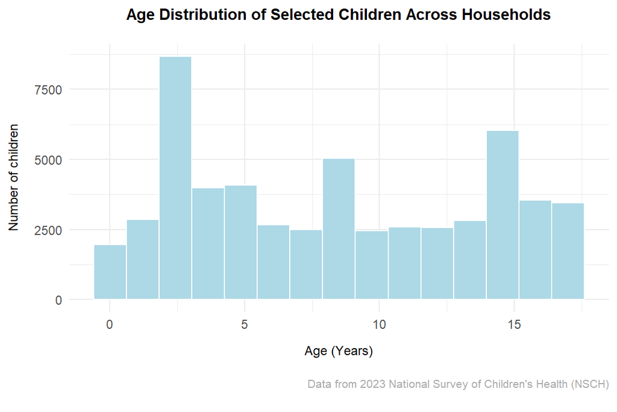

```r
# Histogram of Age
ggplot(df, aes(x = age)) +
  geom_histogram(bins = 15, fill = "lightblue", color = "white") +
  labs(title = "Age Distribution of Selected Children Across Households",
       x = "Age (Years)",
       y = "Number of children",
       caption = "Data from 2023 National Survey of Children's Health (NSCH)") +
  theme_minimal() +
  theme(
    plot.title = element_text(size = 11,
                              face = "bold",
                              margin = margin(b = 15),
                              hjust = 0.5),
    axis.title.x = element_text(margin = margin(t = 10), size = 9),
    axis.title.y = element_text(margin = margin(r = 10), size = 9),
    plot.caption = element_text(
      size = 8,
      color = "darkgray",
      margin = margin(t = 15, b = 10, unit = "pt")
    ))
```

## Distribution of Age by Age Group

To confirm that our age categories behaved as intended, we created a boxplot showing the distribution of age within each of the four age groups. Each group spanned its expected range with no overlap between them, verifying that children were correctly partitioned into infants and toddlers (0–2), preschool (3–5), middle childhood (6–12), and adolescents (13–17). This grouping formed the basis for our later age-stratified analysis.

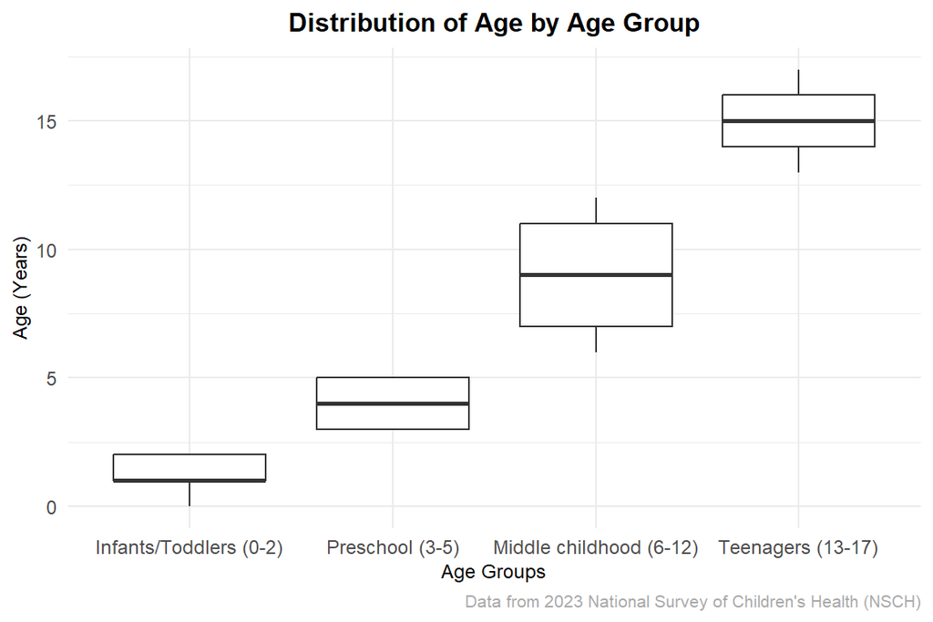

```r
# Boxplot of age within group

ggplot(df, aes(x = age_cats, y = age)) +
  geom_boxplot() +
  labs(title = "Distribution of Age by Age Group",
       x = "Age Groups",
       y = "Age (Years)",
       caption = "Data from 2023 National Survey of Children's Health (NSCH)") +
  theme_minimal() +
  theme(
    plot.title = element_text(size = 12, face = "bold", hjust = 0.5),
    plot.subtitle = element_text(size = 10, color = "gray30", hjust = 0.5),
    axis.text = element_text(size = 9),
    axis.title.x = element_text(size = 9),
    axis.title.y = element_text(size = 9),
    legend.text = element_text(size = 9),
    legend.title = element_text(size = 9),
    legend.position = "none",
    plot.caption = element_text(size = 8, color = "darkgray")
  )
```

## Asthma Prevalence by Birth Weight and Age

[figure not shown]

```r
df |>
  filter(!is.na(birth_weight_low), !is.na(asthma), !is.na(age_cats)) |>
  group_by(age_cats, birth_weight_low) |>
  summarise(pct = 100 * mean(asthma == "Yes"), .groups = "drop") |>
  ggplot(aes(x = age_cats, y = pct, fill = birth_weight_low)) +
  geom_col(position = position_dodge(width = 0.8), width = 0.7) +
  geom_text(aes(label = paste0(round(pct, 1), "%")),
            position = position_dodge(width = 0.8),
            vjust = -0.4, size = 3) +
  scale_fill_manual(values = c("No" = "steelblue", "Yes" = "lightblue"),
                    labels = c("Normal", "Low birth weight")) +
  labs(title = "Asthma Prevalence by Birth Weight and Age Group",
       subtitle = "Low-birth-weight children have higher prevalence at every age",
       x = NULL, y = "% ever diagnosed with asthma", fill = "Birth weight",
       caption = "Data from 2023 National Survey of Children's Health (NSCH)") +
  theme_minimal(base_size = 16) +
  theme(
    plot.title = element_text(size = 12, face = "bold", hjust = 0.5),
    plot.subtitle = element_text(size = 10, color = "gray30", hjust = 0.5),
    axis.text = element_text(size = 9),
    axis.title.y = element_text(size = 9),
    legend.text = element_text(size = 9),
    legend.title = element_text(size = 9),
    legend.position = "top",
    plot.caption = element_text(size = 8, color = "darkgray")
  )
```

# Table 2: Unadjusted and adjusted association between low birth weight and ever having an asthma diagnosis

To formally test the association between low birth weight and asthma, we fit a staged sequence of logistic regression models, presented in Table 2. The first model was unadjusted, the second adjusted for child age, and the third adjusted for the full set of covariates (sex, race, preterm birth, familial poverty ratio, parental education, insurance type, and household smoker status). For each model we report both the odds ratio and the absolute prevalence difference with 95% confidence intervals, since the two measures convey complementary information about the relative and absolute magnitude of the association.

```r
tbl <- tribble(
  ~birth_weight,         ~events,       ~unadj_pd,          ~unadj_or,          ~age_pd,            ~age_or,            ~all_pd,            ~all_or,
  "Normal birth weight", "4,358 (9.1)", "Reference",        "1.00",             "Reference",        "1.00",             "Reference",        "1.00",
  "Low birth weight",    "661 (14.3)",  "5.2 (4.1 to 6.2)", "1.67 (1.52–1.82)", "5.1 (4.1 to 6.1)", "1.67 (1.53–1.83)", "1.68 (0.66–2.71)", "1.21 (1.08–1.35)",
  "Missing",             "190 (8.7)",   "",                 "",                 "",                 "",                 "",                 ""
)

tbl |>
  gt(rowname_col = "birth_weight") |>
  # Row-group label that spans the exposure rows
  tab_row_group(
    label = md("**Exposure = birth weight category**"),
    rows  = everything()
  ) |>
  # Top-level spanning headers
  tab_spanner(label = "Events, N=52,935",           columns = events) |>
  tab_spanner(label = "Unadjusted, N=52,532",        columns = c(unadj_pd, unadj_or)) |>
  tab_spanner(label = "Adjusted for age, N=52,532",  columns = c(age_pd, age_or)) |>
  tab_spanner(label = "Adjusted for all variables,* N=50,580",
              id = "all_var", columns = c(all_pd, all_or)) |>
  # Sub-column labels
  cols_label(
    events   = "",
    unadj_pd = "Prevalence difference % (95% CI)",
    unadj_or = "Odds ratio (95% CI)",
    age_pd   = "Prevalence difference % (95% CI)",
    age_or   = "Odds ratio (95% CI)",
    all_pd   = "Prevalence difference % (95% CI)",
    all_or   = "Odds ratio (95% CI)"
  ) |>
  cols_align(align = "center", columns = -birth_weight) |>
  # The asterisk footnote
  tab_footnote(
    footnote  = "Abbreviations, CI = Confidence interval",
    locations = cells_column_spanners(spanners = "all_var")
  ) |>
  tab_footnote(
    footnote  = "Unadjusted and adjusted results were estimated using logistic regression",
    locations = cells_stub(rows = birth_weight == "Low birth weight")
  ) |>
  tab_footnote(
    footnote  = "Adjusted for age, sex, race, preterm birth, familial poverty ratio, education level of adults, insurance type, andhousehold smoker status",
    locations = cells_stub(rows = birth_weight == "Low birth weight")
  )
```

|  | Events, N=52,935 | Unadjusted, N=52,532 Prevalence difference % (95% CI) | Unadjusted, N=52,532 Odds ratio (95% CI) | Adjusted for age, N=52,532 Prevalence difference % (95% CI) | Adjusted for age, N=52,532 Odds ratio (95% CI) | Adjusted for all variables,* N=50,580<sup>1</sup> Prevalence difference % (95% CI) | Adjusted for all variables,* N=50,580<sup>1</sup> Odds ratio (95% CI) |
| --- | --- | --- | --- | --- | --- | --- | --- |
| **Exposure = birth weight category** |  |  |  |  |  |  |  |
| Normal birth weight | 4,358 (9.1) | Reference | 1.00 | Reference | 1.00 | Reference | 1.00 |
| Low birth weight<sup>2,3</sup> | 661 (14.3) | 5.2 (4.1 to 6.2) | 1.67 (1.52–1.82) | 5.1 (4.1 to 6.1) | 1.67 (1.53–1.83) | 1.68 (0.66–2.71) | 1.21 (1.08–1.35) |
| Missing | 190 (8.7) |  |  |  |  |  |  |

<sup>1</sup> Abbreviations, CI = Confidence interval  
<sup>2</sup> Unadjusted and adjusted results were estimated using logistic regression  
<sup>3</sup> Adjusted for age, sex, race, preterm birth, familial poverty ratio, education level of adults, insurance type, andhousehold smoker status

## Logistic Regression

Having summarized the results in Table 2, we present the full logistic regression models below. Each model is shown in a staged sequence (unadjusted, age-adjusted, and fully adjusted) with the complete model output and the odds ratios and confidence intervals for every term.

We used logistic regression because our outcome, ever having an asthma diagnosis, is binary. To separate the effect of low birth weight from the influence of other factors, we built the models in a staged sequence rather than fitting a single model. The first model was unadjusted, estimating the crude association between low birth weight and asthma. The second added child age alone, since age was fully observed and allowed us to check whether it confounded the relationship before introducing covariates with missing data. The third model was fully adjusted for sex, race, preterm birth, familial poverty ratio, parental education, insurance type, and household smoker status. Building the models in stages let us see how the association changed as covariates were added and to account for the effect of missing covariate data on the sample size at each step.

### Model 1: Unadjusted

```r
# Relevel binary variables so "No" is the reference category
# This makes every odds ratio read in the intuitive direction (exposed vs. unexposed).

df$birth_weight_low <- relevel(df$birth_weight_low, ref = "No")  # OR = low vs normal birth weight
df$born_early       <- relevel(df$born_early, ref = "No")        # OR = preterm vs full-term
df$asthma           <- relevel(df$asthma, ref = "No")            # model P(asthma = Yes)
df$cigarettes       <- relevel(df$cigarettes, ref = "No")        # OR = smoker vs non-smoker household
```

```r
# Model 1: unadjusted asthma on low birth weight
model1 <- glm(asthma ~ birth_weight_low, data = df, family = binomial)

# full model output (coefficients, SEs, fit stats)
summary(model1)
```

```
Call:
glm(formula = asthma ~ birth_weight_low, family = binomial, data = df)

Coefficients:
                    Estimate Std. Error z value Pr(>|z|)
(Intercept)         -2.30183    0.01589 -144.88   <2e-16 ***
birth_weight_lowYes  0.51007    0.04492   11.36   <2e-16 ***
---
Signif. codes:  0 '***' 0.001 '**' 0.01 '*' 0.05 '.' 0.1 ' ' 1

(Dispersion parameter for binomial family taken to be 1)

    Null deviance: 33114  on 52531  degrees of freedom
Residual deviance: 32996  on 52530  degrees of freedom
  (2630 observations deleted due to missingness)
AIC: 33000

Number of Fisher Scoring iterations: 5
```

```r
# odds ratio + 95% CI
tidy(model1, exponentiate = TRUE, conf.int = TRUE)
```

```
# A tibble: 2 × 7
  term                estimate std.error statistic  p.value conf.low conf.high
  <chr>                  <dbl>     <dbl>     <dbl>    <dbl>    <dbl>     <dbl>
1 (Intercept)            0.100    0.0159    -145.  0          0.0970     0.103
2 birth_weight_lowYes    1.67     0.0449      11.4 6.92e-30   1.52       1.82
```

*Interpretation:*

Model 1 is unadjusted and shows a significant association between birth weight status and asthma (OR = 1.67, 95% CI: 1.52–1.82, p < 0.001). Since the reference level is normal birth weight, this odds ratio compares low-birth-weight children to normal-birth-weight children directly. Low-birth-weight children had about 1.67 times the odds of an asthma diagnosis compared to normal-birth-weight children. This finding is consistent with the crude prevalences observed in the sample, 14.3% of low-birth-weight children had an asthma diagnosis compared to 9.1% of normal-birth-weight children, and it supports the study’s underlying hypothesis.

### Model 2: Adjusted for Age

```r
# Model 2: asthma on low birth weight, age-adjusted
model2 <- glm(asthma ~ birth_weight_low + age, data = df, family = binomial)

# full model output (coefficients, SEs, fit stats)
summary(model2)
```

```
Call:
glm(formula = asthma ~ birth_weight_low + age, family = binomial,
    data = df)

Coefficients:
                     Estimate Std. Error z value Pr(>|z|)
(Intercept)         -3.198173   0.034571  -92.51   <2e-16 ***
birth_weight_lowYes  0.515786   0.045582   11.32   <2e-16 ***
age                  0.095284   0.002922   32.60   <2e-16 ***
---
Signif. codes:  0 '***' 0.001 '**' 0.01 '*' 0.05 '.' 0.1 ' ' 1

(Dispersion parameter for binomial family taken to be 1)

    Null deviance: 33114  on 52531  degrees of freedom
Residual deviance: 31875  on 52529  degrees of freedom
  (2630 observations deleted due to missingness)
AIC: 31881

Number of Fisher Scoring iterations: 5
```

```r
# odds ratios + 95% CIs for every term
tidy(model2, exponentiate = TRUE, conf.int = TRUE)
```

```
# A tibble: 3 × 7
  term                estimate std.error statistic   p.value conf.low conf.high
  <chr>                  <dbl>     <dbl>     <dbl>     <dbl>    <dbl>     <dbl>
1 (Intercept)           0.0408   0.0346      -92.5 0           0.0381    0.0437
2 birth_weight_lowYes   1.67     0.0456       11.3 1.10e- 29   1.53      1.83
3 age                   1.10     0.00292      32.6 3.65e-233   1.09      1.11
```

**Interpretation:**

Model 2 adds child age as a covariate. After adjusting for age, the birth weight association is essentially unchanged, OR = 1.67 (95% CI: 1.53–1.83, p < 0.001), nearly identical to Model 1. Low-birth-weight children continued to have about 1.67 times the odds of an asthma diagnosis compared to normal-birth-weight children. Age itself was also significantly associated with asthma, OR = 1.10 per year (95% CI: 1.09–1.11, p < 0.001), meaning each additional year of age was associated with roughly 10% higher odds of an ever asthma diagnosis, consistent with the fact that diagnoses accumulate as children get older. Because the birth weight odds ratio remained stable after adjusting for age, this indicates that age is not confounding the relationship between birth weight and asthma.

### Model 3: Adjusted for age, sex, race, preterm birth, familial poverty ratio, education level of adults, insurance type, and household smoker status

```r
# Model 3: fully adjusted logistic regression of asthma
model3 <- glm(asthma ~ birth_weight_low + age + sex + race + born_early
              + poverty + education + insurance_type + cigarettes,
              data = df, family = binomial)

# full model output (coefficients, SEs, fit stats)
summary(model3)
```

```
Call:
glm(formula = asthma ~ birth_weight_low + age + sex + race +
    born_early + poverty + education + insurance_type + cigarettes,
    family = binomial, data = df)

Coefficients:
                                                 Estimate Std. Error z value
(Intercept)                                    -3.1357821  0.1128916 -27.777
birth_weight_lowYes                             0.1924289  0.0565695   3.402
age                                             0.0967118  0.0030398  31.816
sexFemale                                      -0.3610196  0.0314118 -11.493
raceBlack or African American                   0.6256013  0.0528833  11.830
raceAmerican Indian or Alaska Native            0.1853417  0.1486602   1.247
raceAsian                                      -0.1984254  0.0718400  -2.762
raceNative Hawaiian and other Pacific Islander  0.1894889  0.2191447   0.865
raceTwo or more races                           0.3315935  0.0510043   6.501
born_earlyYes                                   0.4830075  0.0505906   9.547
poverty                                        -0.0001191  0.0001605  -0.742
educationHigh school                            0.1671360  0.1115279   1.499
educationSome college                           0.2721560  0.1091599   2.493
educationCollege degree or higher               0.2023212  0.1098820   1.841
insurance_typePrivate                          -0.2991717  0.0468320  -6.388
insurance_typePrivate and Public                0.1712852  0.0676474   2.532
insurance_typeNot insured                      -0.4262429  0.0876601  -4.862
cigarettesYes                                   0.0942504  0.0479862   1.964
                                               Pr(>|z|)
(Intercept)                                     < 2e-16 ***
birth_weight_lowYes                             0.00067 ***
age                                             < 2e-16 ***
sexFemale                                       < 2e-16 ***
raceBlack or African American                   < 2e-16 ***
raceAmerican Indian or Alaska Native            0.21249
raceAsian                                       0.00574 **
raceNative Hawaiian and other Pacific Islander  0.38722
raceTwo or more races                          7.96e-11 ***
born_earlyYes                                   < 2e-16 ***
poverty                                         0.45814
educationHigh school                            0.13398
educationSome college                           0.01266 *
educationCollege degree or higher               0.06558 .
insurance_typePrivate                          1.68e-10 ***
insurance_typePrivate and Public                0.01134 *
insurance_typeNot insured                      1.16e-06 ***
cigarettesYes                                   0.04952 *
---
Signif. codes:  0 '***' 0.001 '**' 0.01 '*' 0.05 '.' 0.1 ' ' 1

(Dispersion parameter for binomial family taken to be 1)

    Null deviance: 31777  on 50579  degrees of freedom
Residual deviance: 29985  on 50562  degrees of freedom
  (4582 observations deleted due to missingness)
AIC: 30021

Number of Fisher Scoring iterations: 5
```

```r
# odds ratios + 95% CIs for every term
tidy(model3, exponentiate = TRUE, conf.int = TRUE)
```

```
# A tibble: 18 × 7
   term                estimate std.error statistic   p.value conf.low conf.high
   <chr>                  <dbl>     <dbl>     <dbl>     <dbl>    <dbl>     <dbl>
 1 (Intercept)           0.0435  0.113      -27.8   8.24e-170   0.0347    0.0540
 2 birth_weight_lowYes   1.21    0.0566       3.40  6.70e-  4   1.08      1.35
 3 age                   1.10    0.00304     31.8   3.94e-222   1.10      1.11
 4 sexFemale             0.697   0.0314     -11.5   1.43e- 30   0.655     0.741
 5 raceBlack or Afric…   1.87    0.0529      11.8   2.74e- 32   1.68      2.07
 6 raceAmerican India…   1.20    0.149        1.25  2.12e-  1   0.890     1.60
 7 raceAsian             0.820   0.0718      -2.76  5.74e-  3   0.711     0.942
 8 raceNative Hawaiia…   1.21    0.219        0.865 3.87e-  1   0.769     1.82
 9 raceTwo or more ra…   1.39    0.0510       6.50  7.96e- 11   1.26      1.54
10 born_earlyYes         1.62    0.0506       9.55  1.33e- 21   1.47      1.79
11 poverty               1.00    0.000160    -0.742 4.58e-  1   1.00      1.00
12 educationHigh scho…   1.18    0.112        1.50  1.34e-  1   0.954     1.48
13 educationSome coll…   1.31    0.109        2.49  1.27e-  2   1.06      1.63
14 educationCollege d…   1.22    0.110        1.84  6.56e-  2   0.991     1.53
15 insurance_typePriv…   0.741   0.0468      -6.39  1.68e- 10   0.676     0.813
16 insurance_typePriv…   1.19    0.0676       2.53  1.13e-  2   1.04      1.35
17 insurance_typeNot …   0.653   0.0877      -4.86  1.16e-  6   0.548     0.773
18 cigarettesYes         1.10    0.0480       1.96  4.95e-  2   0.999     1.21
```

**Interpretation**

Model 3 adds the full covariate set, sex, race, preterm birth, familial poverty ratio, education level of adults, insurance type, and household smoker status, on top of age. After this full adjustment, the birth weight association attenuates meaningfully: OR = 1.21 (95% CI: 1.08–1.35, p < 0.001), down from OR = 1.67 in both Model 1 and Model 2. Low-birth-weight children had about 1.21 times the odds, a 21% increase in odds, of an ever asthma diagnosis compared to normal-birth-weight children, holding the other covariates constant. However, this association remains statistically significant, since the 95% confidence interval does not cross 1.00, though the magnitude is now notably smaller than in the unadjusted and age-adjusted models.

This attenuation indicates that part of the crude birth weight-asthma association was confounded by the additional covariates introduced in this model, rather than reflecting a direct effect of birth weight alone. Race is the strongest driver of this attenuation: Black children had substantially higher odds of an asthma diagnosis than White children (OR ≈ 1.87, p < 0.001), the largest independent association of any covariate in the model. Preterm birth also contributed meaningfully (OR ≈ 1.62, p < 0.001) and is strongly correlated with low birth weight, so some of the crude birth weight effect seen in Models 1 and 2 was likely capturing the combined influence of race and prematurity rather than low birth weight operating independently. Insurance type was also significantly associated with asthma diagnosis, contributing further to the attenuation. Familial poverty ratio, by contrast, was not significantly associated with asthma in this model (p = 0.458), despite being included in the adjustment set.

Because the birth weight odds ratio drops substantially once these covariates are added, race, preterm birth, and insurance type appear to confound part of the crude birth weight-asthma relationship. Even so, a statistically significant association between low birth weight and asthma persists after full adjustment, suggesting that low birth weight retains an independent relationship with asthma risk beyond what these covariates alone can explain.

### Model 3 Visualizations

To make the model results easier to interpret, we created several visualizations. First, a predicted-probability plot shows how the estimated probability of an asthma diagnosis changes across age for low- versus normal-birth-weight children, translating the model’s odds ratios onto the more intuitive probability scale. Second, a coefficient plot displays the adjusted odds ratios for every predictor in the fully adjusted model on a single axis, allowing quick comparison of which factors raise or lower the odds of asthma and which are statistically significant. Together, these plots summarize the fully adjusted model both in terms of its central finding (the birth-weight effect across age) and its full set of covariates.

#### Predicted Probabilities Plot

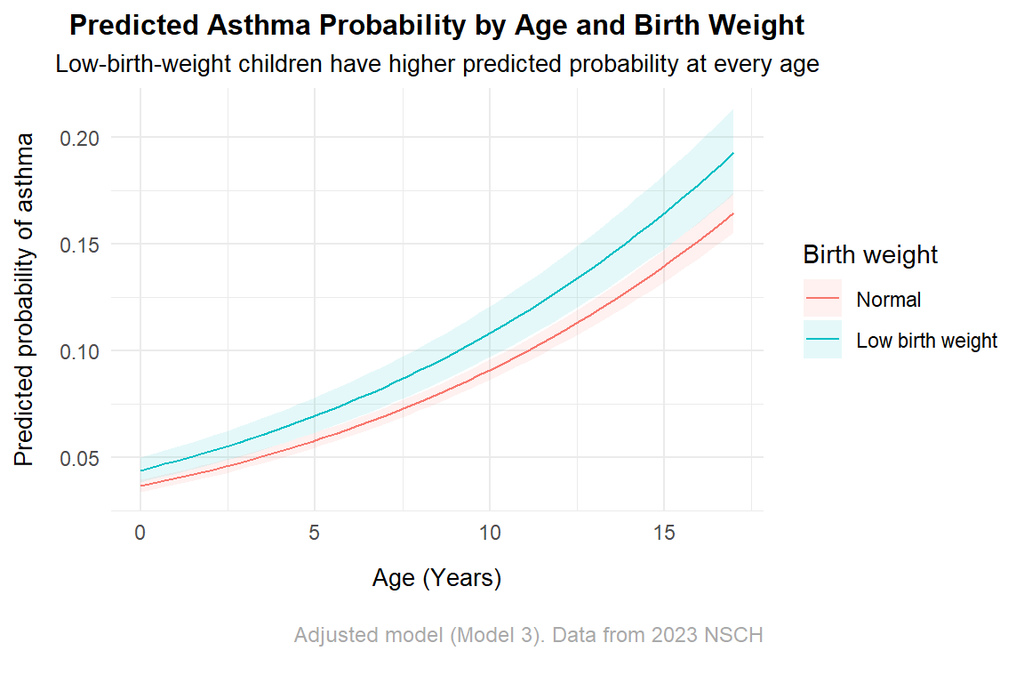

```r
# Predicted asthma probability by age and birth weight (Model 3)
plot_predictions(model3, condition = c("age", "birth_weight_low")) +
  scale_color_discrete(labels = c("Normal", "Low birth weight")) +
  scale_fill_discrete(labels = c("Normal", "Low birth weight")) +
  labs(title = "Predicted Asthma Probability by Age and Birth Weight",
       subtitle = "Low-birth-weight children have higher predicted probability at every age",
       x = "Age (Years)", y = "Predicted probability of asthma",
       color = "Birth weight", fill = "Birth weight",
       caption = "Adjusted model (Model 3). Data from 2023 NSCH") +
  theme_minimal() +
  theme(
    plot.title = element_text(size = 12,
                              face = "bold",
                              hjust = 0.5),
    plot.subtitle = element_text(size = 10, hjust = 0.5),
    axis.title.x = element_text(margin = margin(t = 10), size = 10),
    axis.title.y = element_text(margin = margin(r = 10), size = 10),
    plot.caption = element_text(
      size = 9,
      color = "darkgray",
      margin = margin(t = 15, b = 10, unit = "pt")
    ))
```

*Interpretation:*

*Predicted asthma probability rises steadily with age in both groups, from about 4–5% at birth to 16–19% by age 17 which is consistent with the age odds ratio of 1.10 (asthma diagnoses accumulate as children get older). Low-birth-weight children (blue) sit above normal-birth-weight children (red) at every age, showing the adjusted birth-weight effect (OR = 1.21) holds across all of childhood. The gap between the two curves widens in absolute terms at older ages. This is expected on the probability scale, since a constant odds ratio produces a larger percentage-point difference when the baseline probability is higher. The confidence bands overlap modestly, reflecting that the adjusted birth-weight association, while significant, is smaller than the crude one.*